# Partie 2 Services: Carbone, Diversité

Elsa SANIAL

11 juin 2018

# Estimation de la biomasse aérienne des arbres associés aux cacaoyers

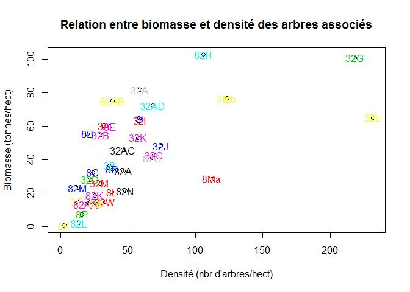

```
## integer(0)
```

```
##     code     densit    biomhect
## 24   32A  59.154096  81.8021298
## 25  32AA  22.320000  15.0925982
## 27  32AC  46.500000  45.7471246
## 28  32AD  68.300000  72.3558904
## 29   32B  29.781602  54.9290289
## 30   32C  69.406393  42.8271867
## 31   32D  21.673891  28.1270110
## 34   32G 218.403151 100.8940709
## 36   32I  59.128930  63.4311049
## 37   32J  74.503960  48.1523417
## 38   32K  57.503394  53.2834502
## 39   32L 231.670755  65.1969879
## 40   32M  29.290519  25.9020343
## 50   32W  33.330000  14.8287012
```

[output cut: 23 more lines]

# Estimation de la biomasse aérienne des cacaoyers

## Estimation de la densité des cacaoyers (nbr cacaoyers/hect)

La densité de cacaoyers n’a pas été mesurée sur les parcelles inventoriées.

Toutefois, je dispose d’un jeu de données constitué lors de mon Master 2 (avec IDH/CIRAD/ALP). J’avais mesuré les densités de cacaoyers sur 61 parcelles de 12 à 52 ans dans l’ouest ivoirien. Sur chaque parcelle, les cacaoyers ont été comptés dans 4 carrés de 100m² (Sanial, 2015, Ruf et al., 2015). J’ai ensuite calculé la densité moyenne de ces 4 carrés pour chaque parcelle. Dans ce jeu de données, la relation entre âge du champ et densité peut s’écrire selon l’équation suivante -4.509ln(x)+29.97.

Ainsi, j’ai pu estimer la densité des cacaoyers en fonction de l’âge pour chacune des parcelles inventoriées dans le cadre de me thèse.

L’estimation de la densité moyenne des cacaoyers (nbr cacaoyers/hectares) ( [1] 1588.314 ) est supérieure à ce qui a été mesuré par Stemler (2012): 1100 cacaoyers/hectares dans le sud Ivoirien.

Toutefois, lors des inventaires botaniques, les portions de la parcelle n’ayant pas de cacaoyers ont été cartographiées au GPS. Cela permet de connaître le pourcentage d’espaces vides de cacaoyers par rapport à la superficie totale inventoriée. Une fois ce pourcentage pris en compte on obtient une densité de cacaoyers à l’hectare plus faible avec une moyenne de:

[1] 1477.866 cacaoyers par hectare .

On pourrait également enlever de la superficie totale la surface terrière des arbres, mais elle est tellement faible que cela n’impactera que peu le résultat.

Il faudrait plutôt prendre en compte l’effet de certaines essences d’arbres compagnons sur la densité des cacaoyers (pas de cacaoyers autour du pied de ces arbres: Samba, Manguiers, Orangers, Tigleti,..) (voir méthode n°2 ci-dessous).

## Méthode n°1:estimation de la biomasse aérienne des cacaoyers (tonnes/hectare)

Dans cette méthode on ne prend pas en compte l’effet de l’ombrage sur la biomasse des cacaoyers ni celui de la présence d’arbres compagnons sur la densité de cacaoyers.

La biomasse aérienne du cacaoyer, d’après le modèle de Zuidema et al.,(2005), représente 88.2% de la biomasse totale (d’après la compilation de différentes mesures effectuées au Brésil, Congo, Costa Rica, Malaysie, Nigeria et Vénézuela). La régression logarithmique entre l’âge de l’arbre et la biomasse est, toujours d’après ce modèle physiologique : 8.46ln(x)+9.40.

J’utilise cette équation pour estimer la biomasse des cacaoyers en prenant en compte l’âge de la plantation (compris ici, de manière schématique comme l’âge du cacaoyer).

On obtient ainsi la biomasse totale. Pour obtenir une estimation de la biomasse aérienne pour chaque cacaoyer, il faut prendre 88.2% de la biomasse totale.

```r
Carbonestimated$kkobiomasse<-((((8.46*log(Carbonestimated$age_champ)+9.4)*88.2)/100)*Carbonestimated$kkodensitmoinsparc)/1000
#Limite de ce calcul: les données sont prises sur des plantations ombragées, donc avec plus de biomasse cacaoyère.
```

## Méthode n°2: estimation de la biomasse aérienne des cacaoyers (prise en compte de l’effet de certains arbres et de l’ombrage)

N’ayant pas trouvé d’étude croisant effet de l’âge et de l’ombrage sur la biomasse cacaoyère, il nous a fallut combiner deux études différentes. Le modèle de Zuidema et al., (2005) se base sur des données expérimentales tirées de plusieurs plantations dont la plupart d’entre elles sont ombragées (ombrage mixte (Aranguren et al., 1982 ), ombrage léger de cocotiers (Teoh et al., 1980), ombrage dense d’agroforêts traditionnelles ( Subler, 1994)).

Les travaux d’Isaac et al., 2007 réalisés au Ghana dans des conditions environnementales proches de celles de mes sites d’inventaire, peuvent être pris en compte pour affiner l’estimation de la biomasse cacaoyère.Cette étude, conduite en plantations expérimentales, vise à mesurer l’effet de l’ombrage sur la biomasse cacaoyère. Quatre combinaisons sont testées dans cette plantation âgée de 8 ans:

- cacaoyers
- cacaoyers complantés avec Albizia
- cacaoyers complantés avec Milicia
- cacaoyers complantés avec Newbouldia.

J’ai comparé ses résultats avec ceux du modèle de Zuidema et al. pour x=8.

Chez Isaac et al. à 8 ans un cacaoyer plein soleil a 20.75kg de biomasse aérienne, un cacaoyer sous un ombrage dense (Milicia excelsa) a 37.2 kg et un cacaoyer sous ombrage léger (Newbouldia laevis) 28 kg. A plus de 5m du pied de l’arbre compagnon quel qu’il soit les biomasses des cacaoyers ne varient que très peu (respectivement 21 kg et 19.7kg) . Ainsi, j’ai retenu de manière schématique que la biomasse augmente avec l’ombrage dans un rayon de 5m autour de l’arbre.

Le modèle de Zuidema et al., pour un âge de 8 ans, donne une biomasse aérienne de 23.8 kg ce qui est supérieur de 13.1% aux résultats de Isaac et al. Cela peut venir du fait que les plantations dont est tiré le modèle sont pour une majeure partie d’entre elles ombragées. Je considère donc que pour obtenir la biomasse aérienne d’un cacaoyer plein soleil il faut baisser le résultat de l’équation de Zuidema de 13.1%.

J’ai ensuite classé les arbres compagnons de mes parcelles en deux grandes catégories:

- ombrage léger (arbres dont le port et l’ombrage sont similaires à celui de Newbouldia laevis)
- ombrage dense (arbres dont le port et l’ombrage sont similaire à celui de Milicia excelsa).

Dans ces deux grandes catégories j’ai sélectionné les individus qui sont plus hauts que les cacaoyers (cette taille varie selon les plantations et cette information a été relevée lors de l’inventaire) et qui leur fournissent donc un ombrage. Ensuite, à l’aide d’un SIG un cercle de 5m de rayon a été tracé autour de ces arbres et l’emprise au sol de ces cercles (schématisant l’ombrage) a été mesurée. Cette méthode permet d’obtenir pour 1 hectare de plantation la proportion de cacaoyers situés en plein soleil, la proportion sous ombrage léger et la proportion sous ombrage dense. A l’aide de la densité de cacaoyers précédemment calculée, on peut donc connaître le nombre de cacaoyers pour chaque type d’ombrage.

Enfin, certains arbres ont un effet sur la densité de cacaoyers. A leur pied, et sur une distance variant selon les espèces, aucun cacaoyer ne pousse. Nos relevés de terrains ont permis de dresser une liste de ces arbres et d’estimer, selon l’espèce, un rayon sur lequel aucun cacaoyer ne pousse. Ces surfaces ont été représentées dans le SIG pour les arbres dont le périmètre est supérieur à 45cm. Elles ont été mesurées puis retirées des catégories correspondantes (plein soleil, ombrage dense, ombrage léger).

Une fois les trois catégories de cacaoyers bien définies, la régression de Zuidema et al. est appliquée à chaque catégorie et pondérée en fonction des résultats d’Isaac et al.: - moins 13.1 % pour le plein soleil - plus 15 % pour l’ombrage léger - plus 36.1% pour l’ombrage dense.

# Estimation de la biomasse totale et du carbone (Tonnes/hect) (arbres compagnons + cacaoyers)

densit= densité des arbres compagnons

biomhect = biomasse des arbres compagnons

kkobiomasse et carbontot= résultat selon la méthode n°1

kkobiomasse2 et carbontot2= résultat selon la méthode n°2

```
##    code    biomhect kkobiomasse kkobiomasse2 carbontot carbontot2
## 1   32A  81.8021298    42.89466     39.13028  62.34839   60.46621
## 2  32AA  15.0925982    44.19060     39.04180  29.64160   27.06720
## 3  32AC  45.7471246    43.73516     37.60363  44.74114   41.67538
## 4  32AD  72.3558904    46.54409     41.73674  59.44999   57.04632
## 5   32B  54.9290289    47.56529     39.48144  51.24716   47.20523
## 6   32C  42.8271867    46.87194     42.82687  44.84956   42.82703
## 7   32D  28.1270110    47.32555     41.63476  37.72628   34.88088
## 8   32G 100.8940709    42.49641     47.56543  71.69524   74.22975
## 9   32I  63.4311049    40.59528     34.40728  52.01319   48.91919
## 10  32J  48.1523417    47.17518     43.15955  47.66376   45.65595
## 11  32K  53.2834502    42.08909     38.18735  47.68627   45.73540
## 12  32L  65.1969879    41.77918     41.46147  53.48809   53.32923
## 13  32M  25.9020343    45.53706     39.98681  35.71955   32.94442
## 14  32W  14.8287012    41.76096     37.17660  28.29483   26.00265
```

[output cut: 23 more lines]

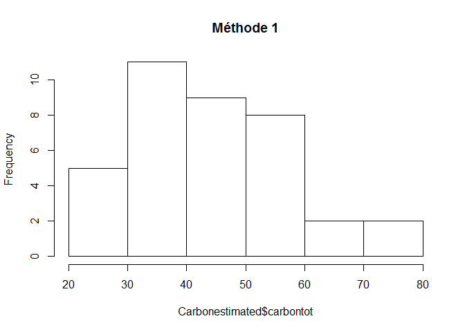

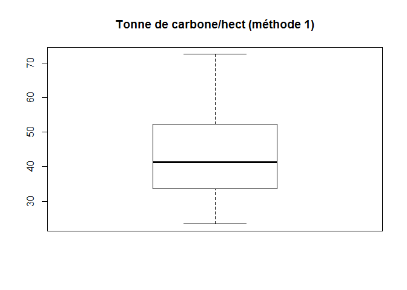

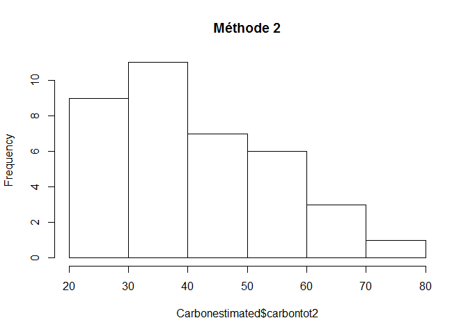

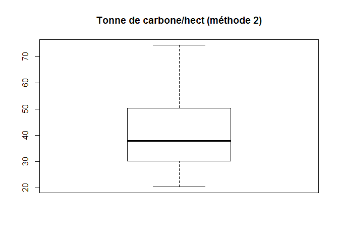

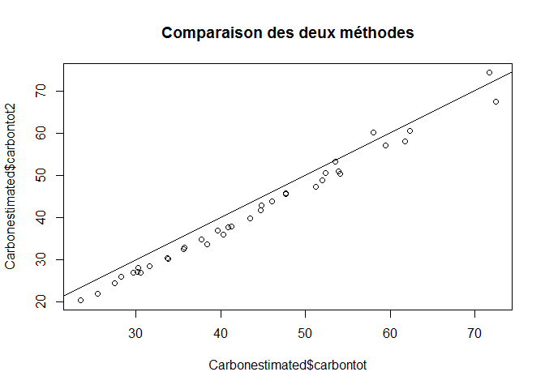

Avec la méthode n°1, les parcelles étudiées stockent de [1] 23.43204 à [1] 72.46179 tonnes de carbone par hectare (cacaoyers+arbres associés).

En moyenne on estime [1] 43.55096 (sd [1] 12.74707 ) tonnes de carbone/hectare.

Avec la méthode n°2, les parcelles étudiées stockent de [1] 20.40188 à [1] 74.22975 tonnes de carbone par hectare (cacaoyers+arbres associés).

En moyenne on estime [1] 40.86765 (sd [1] 13.32683 ) tonnes de carbone/hectare.

Pour indication, d’après Nijmeijer et al., (2017) une agroforêt à cacao camerounaise stocke en moyenne 72 tonnes par hectare (sd 8).

# Estimation du carbone par type d’arbres compagnons (planté, recrû,…)

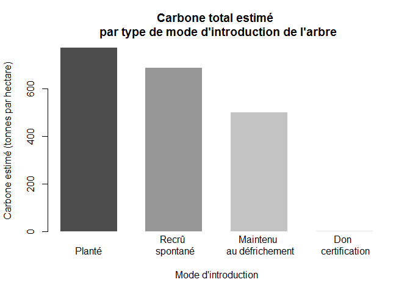

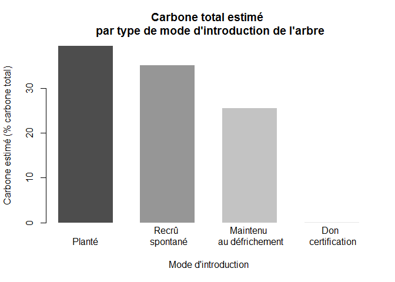

# Covariance Carbone et déterminants environnementaux

## Age

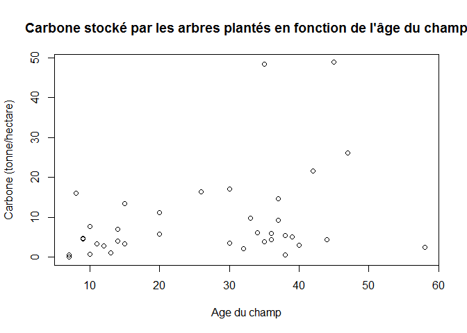

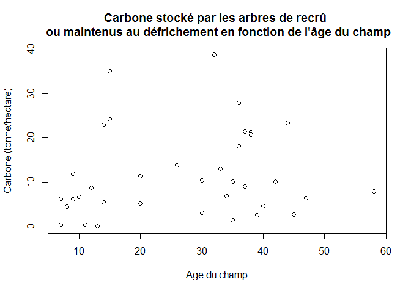

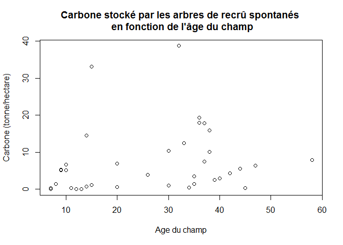

## Occupation des sols

### Bas fonds

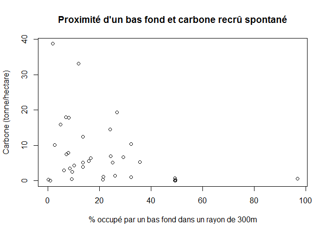

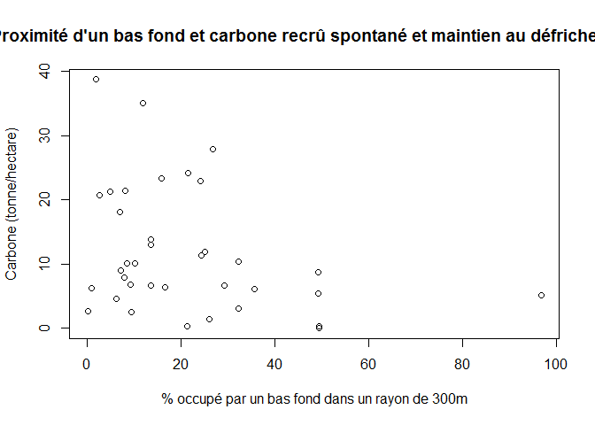

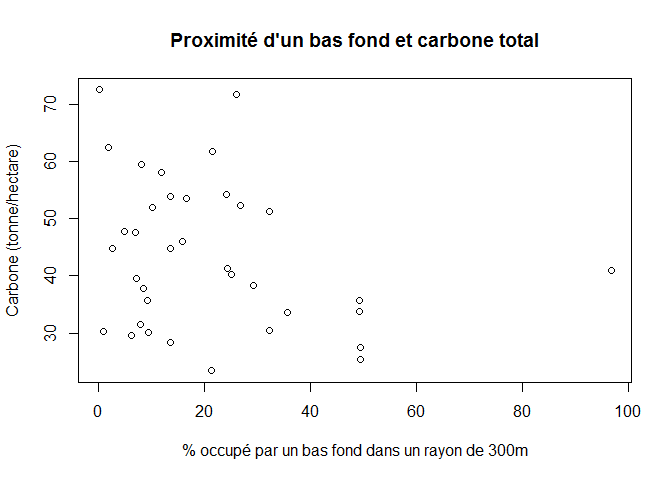

### Cacao

La proximité d’une cacaoyère agroforestière pourrait permettre la diffusion de certaines espèces arborées repoussant spontanément dans les cacaoyères. Ainsi, les parcelles qui se situent au milieu d’un grand bloc de cacaoyères (comme on l’observe souvent) pourraient connaître un recrû spontané plus important et plus variés que celles situées à procximité de bas fonds ou de cultures permanentes.

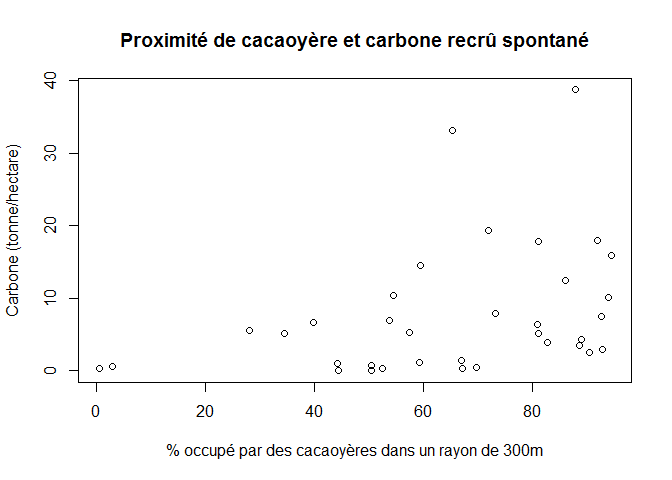

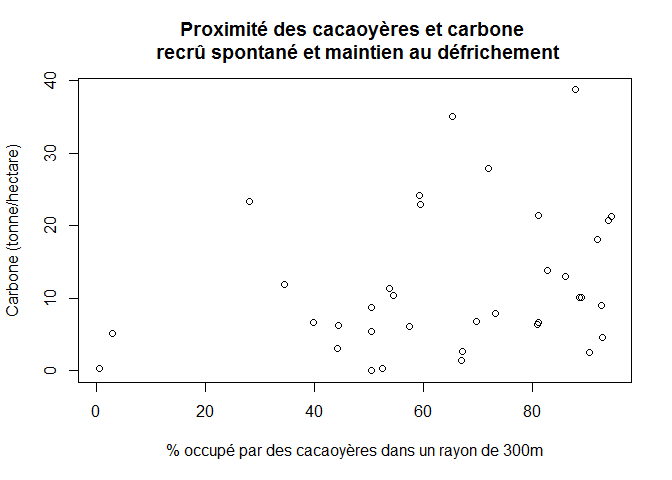

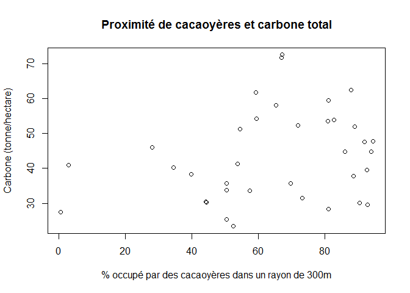

### Forêt

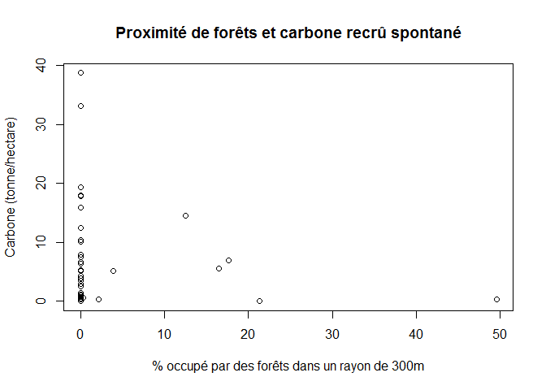

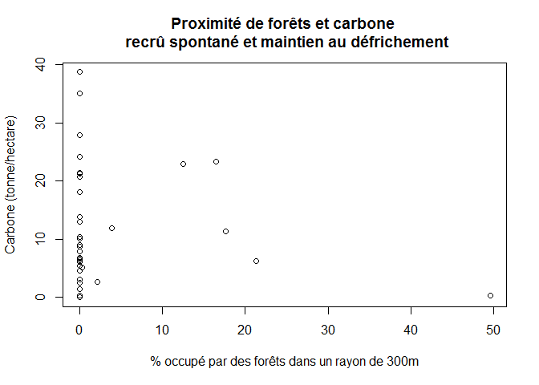

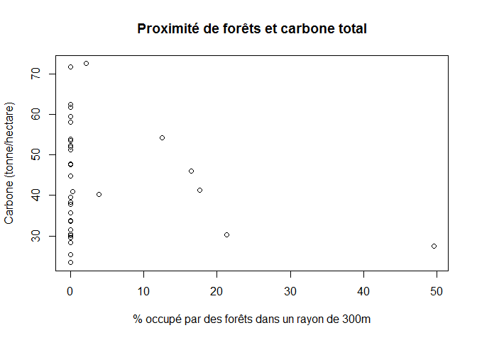

# Service diversité

## Diversité Alpha, Bêta et Gamma pour q=0

```
## Diversity partitioning of order 0 of MetaCommunity Metacom
##
## Alpha diversity of communities:
##  12A  12B  12C  12D  12E  12F  12G  12H  12I  12J  12K  12L  12M  12N  12O
##   17   22    8   11   15   15   25   19   33   21   10   24   17   12   24
##  12P  12Q  12R  12S  12T  15A  15B  15C  32A 32AA 32AB 32AC 32AD  32B  32C
##   15   22   21   11    9   15   16   19   22   14   29   19   14   10   29
##  32D  32E  32F  32G  32H  32I  32J  32K  32L  32M  32N  32O  32P  32Q  32R
##   17   32   22   22   10   22   24   20   30    4   25   11    8   16   25
##  32S  32T  32U  32V  32W  32X  32Y  32Z   3A   3B   3C   3D   3E   3F   3G
##   23   12   13   21   22   25   19   31   15   27    7   21   35   22   16
##   3H   3I   3J   3K   3L   3M   3N   3O   3P   7A   7B   7C   7D   7E   7F
##   27   43   22   11   18   20   21   14    9    5    2   18    5   14   16
##   7G   7H   7I   7J   7K   7L   7M   7N   7O   7P   7Q   7R   7S  82A 82AA
##    4    3   14   11    6    8   14    9   21    8    9   11   11   13   13
## 82AB  82B  82C  82D  82E  82G  82H  82I  82J  82K  82L  82M  82N  82O  82P
##   18    7   11   27    5    8    9   12   10   13    2    9   16    3   10
##  82Q  82R  82S  82T  82U  82V  82W  82X  82Y  82Z   8A   8B   8C   8D   8E
##    6    6   11   11   11   12   12   16   12    8   15   25   15   23   33
##   8F   8G   8H   8I   8J   8K   8L  8Ma  8Mb   8N   8O   8P   8Q   8R   8S
##   10   11   21   13   16    3   15   24   17    8   10    9    7    9    7
##   8T
##   11
## Total alpha diversity of the communities:
## [1] 15.45588
## Beta diversity of the communities:
##     None
## 10.74025
## Gamma diversity of the metacommunity:
## None
##  166
## Quantiles of simulations (alpha, beta and gamma diversity):
##       0%       1%     2.5%       5%      10%      25%      50%      75%
## 15.24199 15.24199 15.26018 15.27838 15.31404 15.39640 15.44787 15.52140
##      90%      95%    97.5%      99%     100%
## 15.58757 15.61993 15.71018 15.74941 15.75669
##       0%       1%     2.5%       5%      10%      25%      50%      75%
## 10.13201 10.21932 10.27105 10.32191 10.41879 10.55298 10.74614 10.94669
##      90%      95%    97.5%      99%     100%
## 11.02681 11.08535 11.14021 11.19277 11.25604
##      0%      1%    2.5%      5%     10%     25%     50%     75%     90%
## 154.730 157.700 158.205 159.680 161.630 163.480 165.730 169.730 170.730
##     95%   97.5%     99%    100%
## 171.730 171.730 171.740 172.730
```

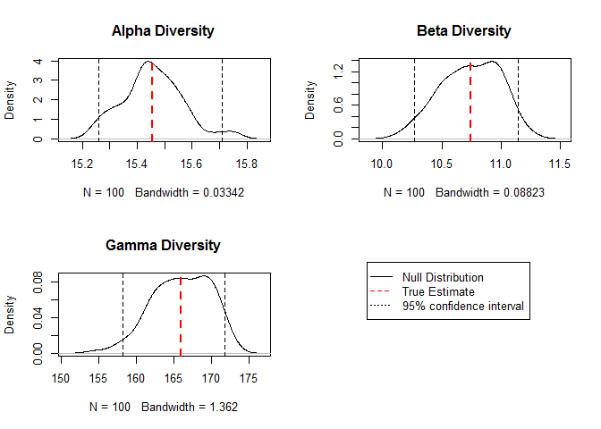

## Diversité Alpha, Bêta et Gamma pour q=2

```
## Diversity partitioning of order 2 of MetaCommunity Metacom
##
## Alpha diversity of communities:
##       12A       12B       12C       12D       12E       12F       12G
## 13.517241 15.428571  4.070423  6.250000  5.261346  7.142857  8.935149
##       12H       12I       12J       12K       12L       12M       12N
## 10.645570  9.513866 12.051793  5.555556 14.670659  6.026786  4.704467
##       12O       12P       12Q       12R       12S       12T       15A
##  5.754425  6.458599 14.237037  3.927119  8.100000  7.200000 11.755556
##       15B       15C       32A      32AA      32AB      32AC      32AD
##  9.876543 10.666667  6.293706 10.593220  9.969231 11.571429  5.345455
##       32B       32C       32D       32E       32F       32G       32H
##  5.027586 13.187215 10.903226 14.635581 16.021978  3.892259  4.878049
##       32I       32J       32K       32L       32M       32N       32O
## 16.643564 14.123631  9.707865 10.946970  1.478702  7.389011  7.666667
##       32P       32Q       32R       32S       32T       32U       32V
##  7.363636 12.894737 14.628571 12.363995  3.313376  6.763380  5.576398
##       32W       32X       32Y       32Z        3A        3B        3C
## 14.485714 14.626087  8.865248 18.213439  6.179021 11.716216  4.281553
##        3D        3E        3F        3G        3H        3I        3J
##  7.993800  8.150028 10.897751 12.041667 15.363636 17.633333 14.285714
##        3K        3L        3M        3N        3O        3P        7A
##  2.282632  6.764588  9.197597  5.174917  4.898004  3.125000  5.000000
##        7B        7C        7D        7E        7F        7G        7H
##  1.246154  9.382979  5.000000 11.764706  1.246883  3.769231  3.000000
##        7I        7J        7K        7L        7M        7N        7O
## 10.795918 10.285714  5.444444  3.841270  5.776000  8.333333 11.982249
##        7P        7Q        7R        7S       82A      82AA      82AB
##  2.716981  2.816626  7.442478  4.130073  4.738318  6.259259  7.297872
##       82B       82C       82D       82E       82G       82H       82I
##  5.666667  6.322581  5.291272  3.200000  1.611150  1.808757 10.125000
##       82J       82K       82L       82M       82N       82O       82P
##  7.474576  9.986301  1.165517  5.444444  5.524459  2.333333  4.263158
##       82Q       82R       82S       82T       82U       82V       82W
##  5.121212  4.411765  8.018182  7.246575  5.225806  6.428571  4.750000
##       82X       82Y       82Z        8A        8B        8C        8D
##  7.229508  7.124629  6.000000 10.880597 12.852459  4.264654  9.285141
##        8E        8F        8G        8H        8I        8J        8K
## 20.362764  4.300813  4.426778  8.237537  6.223529  8.399240  3.000000
##        8L       8Ma       8Mb        8N        8O        8P        8Q
```

[output cut: 9 more lines]

```
##     None
## 19.27162
## Quantiles of simulations (alpha, beta and gamma diversity):
##       0%       1%     2.5%       5%      10%      25%      50%      75%
## 5.034385 5.106221 5.135050 5.194422 5.222711 5.294955 5.394849 5.495461
##      90%      95%    97.5%      99%     100%
## 5.573189 5.609982 5.637613 5.672636 5.689667
##       0%       1%     2.5%       5%      10%      25%      50%      75%
## 3.330508 3.335380 3.350172 3.383020 3.416038 3.486344 3.568693 3.668781
##      90%      95%    97.5%      99%     100%
## 3.724824 3.781537 3.816650 3.821512 3.919297
##       0%       1%     2.5%       5%      10%      25%      50%      75%
## 16.76706 17.94482 18.24595 18.49025 18.60714 18.93269 19.32726 19.68086
##      90%      95%    97.5%      99%     100%
## 20.08145 20.18868 20.26511 20.40233 20.45798
```

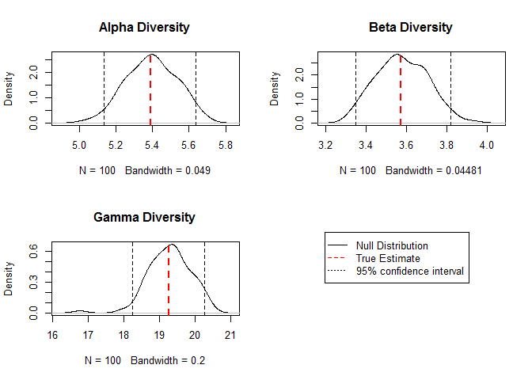

## Diversité Alpha, Bêta et Gamma pour les arbres spontanés

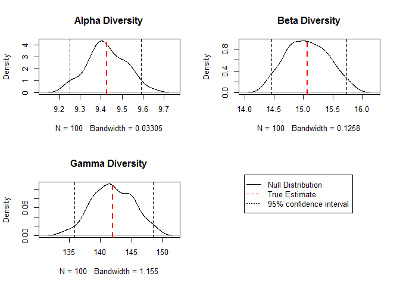

Observation de la covariance entre diversité et carbone: est-ce que plus la parcelle est diverse, plus elle stocke de carbone?

```
##
## Call:
## lm(formula = plot$q0al ~ plot$carbontot)
##
## Residuals:
##      Min       1Q   Median       3Q      Max
## -16.1730  -5.3959  -0.5101   5.7214  23.4149
##
## Coefficients:
##                Estimate Std. Error t value Pr(>|t|)
## (Intercept)      5.0269     4.8587   1.035   0.3079
## plot$carbontot   0.2780     0.1072   2.594   0.0138 *
## ---
## Signif. codes:  0 '***' 0.001 '**' 0.01 '*' 0.05 '.' 0.1 ' ' 1
##
## Residual standard error: 8.198 on 35 degrees of freedom
##   (100 observations deleted due to missingness)
## Multiple R-squared:  0.1612, Adjusted R-squared:  0.1373
## F-statistic: 6.728 on 1 and 35 DF,  p-value: 0.01377
```

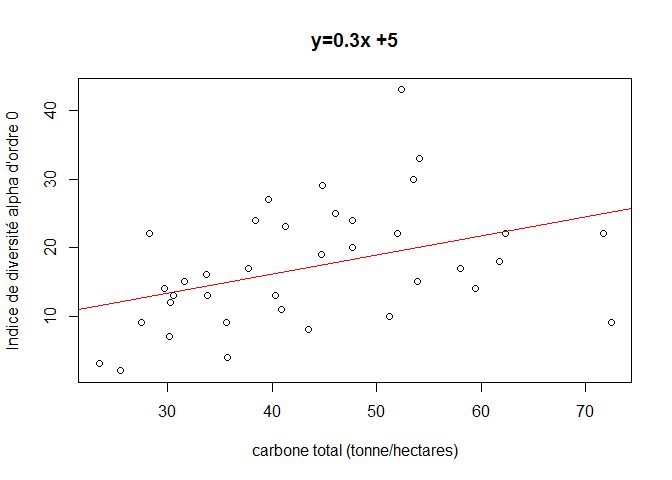

Observation de la covariance entre carbone stocké par le recrû spontané et diversité de ce recrû

```
##
## Call:
## lm(formula = plot$q0alsp ~ plot$carbrec)
##
## Residuals:
##     Min      1Q  Median      3Q     Max
## -11.743  -4.319  -2.178   2.915  17.602
##
## Coefficients:
##              Estimate Std. Error t value Pr(>|t|)
## (Intercept)    5.0635     1.8492   2.738 0.010005 *
## plot$carbrec   0.4417     0.1187   3.723 0.000757 ***
## ---
## Signif. codes:  0 '***' 0.001 '**' 0.01 '*' 0.05 '.' 0.1 ' ' 1
##
## Residual standard error: 6.732 on 32 degrees of freedom
##   (103 observations deleted due to missingness)
## Multiple R-squared:  0.3022, Adjusted R-squared:  0.2804
## F-statistic: 13.86 on 1 and 32 DF,  p-value: 0.0007574
```

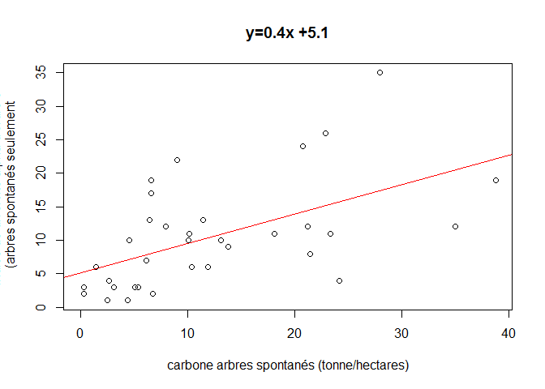

# Covariance Diversité et déterminants environnementaux

## Densité/Diversité

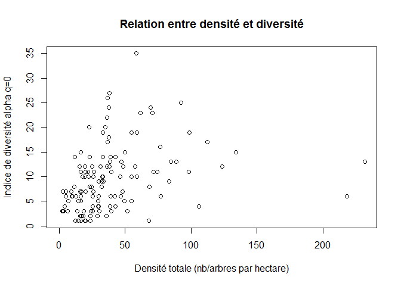

## Age

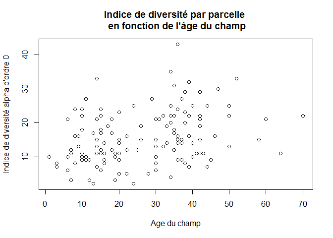

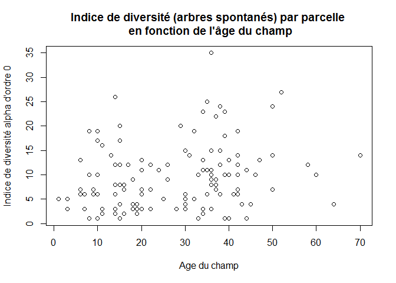

## Occupation des sols: effet sur le recrû spontané

### Bas fonds

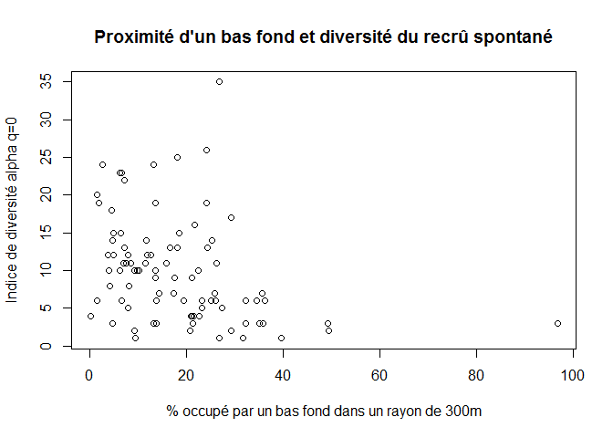

### Cacao

```
##
## Call:
## lm(formula = plot$q0alsp ~ plot$kko)
##
## Residuals:
##     Min      1Q  Median      3Q     Max
## -12.298  -3.905  -1.668   2.389  24.294
##
## Coefficients:
##             Estimate Std. Error t value Pr(>|t|)
## (Intercept)  0.62697    2.23918    0.28     0.78
## plot$kko     0.14015    0.03192    4.39 3.24e-05 ***
## ---
## Signif. codes:  0 '***' 0.001 '**' 0.01 '*' 0.05 '.' 0.1 ' ' 1
##
## Residual standard error: 6.301 on 85 degrees of freedom
##   (50 observations deleted due to missingness)
## Multiple R-squared:  0.1849, Adjusted R-squared:  0.1753
## F-statistic: 19.28 on 1 and 85 DF,  p-value: 3.237e-05
```

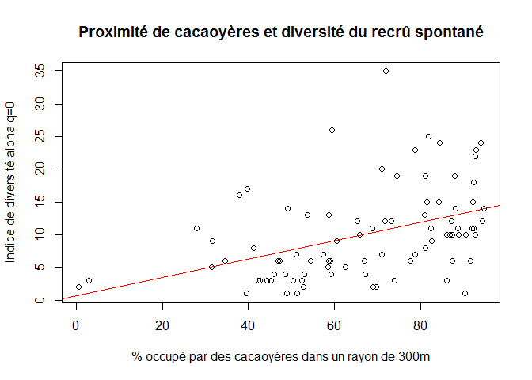

### Forêt

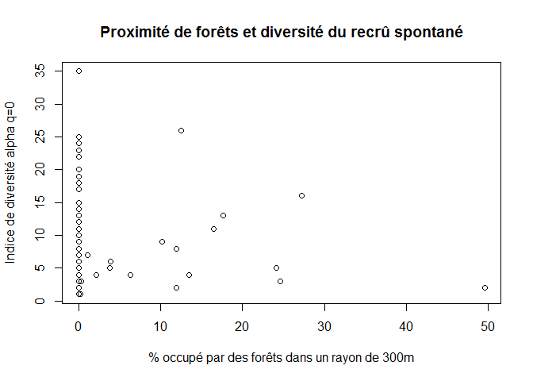

### Autres cultures permanentes en monoculture (palmier, hévéa, teck etc…)

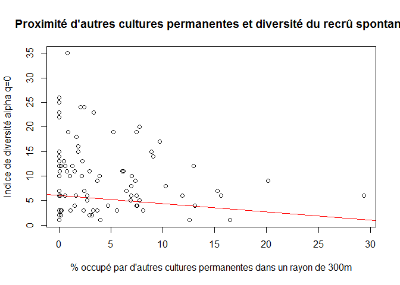